# Bivariate Hypothesis Testing

POLS 2140: Introduction to Political Analysis

Dr. Sarah Dreier

## Reminders and announcements

- **Midterm updates:** Due tomorrow (Oct 23)
- **Paid political internships:** Due next Friday (Oct 30)
  - Info session: Monday 2:00-3:00p, SSCO 2060
- **Honors program:** Application due in two weeks (Nov 6)
- **Karla office hours:** Today 12:30-2:30
- **Class plan:**
  - Data News: Maryam Gauba
  - *Today:* Bivariate hypothesis tests (*Fundamentals* Ch 9)
  - *Tue:* Begin bivariate regression analysis

## Reading Prompt

In your own words: What is a **bivariate hypothesis test** and what does it accomplish?

(Hang on to your response, we’ll return to it later.)

## Recall:

- **GOAL of statistical inference:** Infer what we can about the whole population based on what we **know with certainty** about a sample population.
- **Central Limit Theorem (core underlying principle):** A large, properly drawn random sample will resemble the population from which it is drawn (Wheelan, 2013, p. 128).
- For a single variable, we inferred the **population’s true mean**, specifically the range within which the **population’s true mean** would fall within (at the 95% confidence level).
- **Today:** Are two variables related?

## Are two variables related?

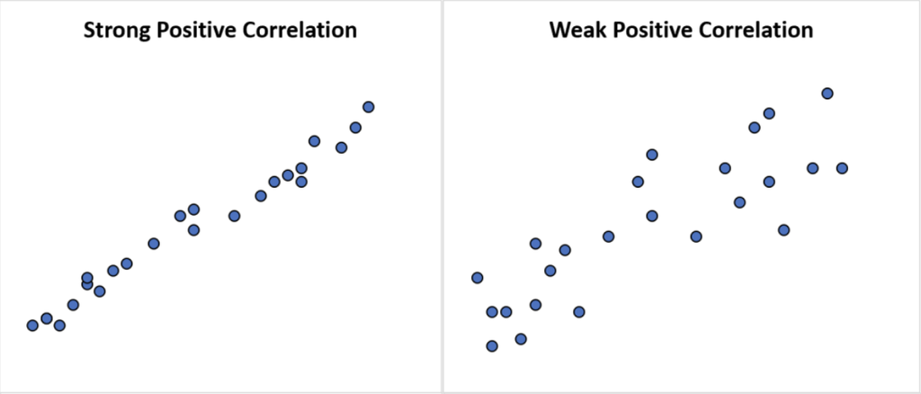

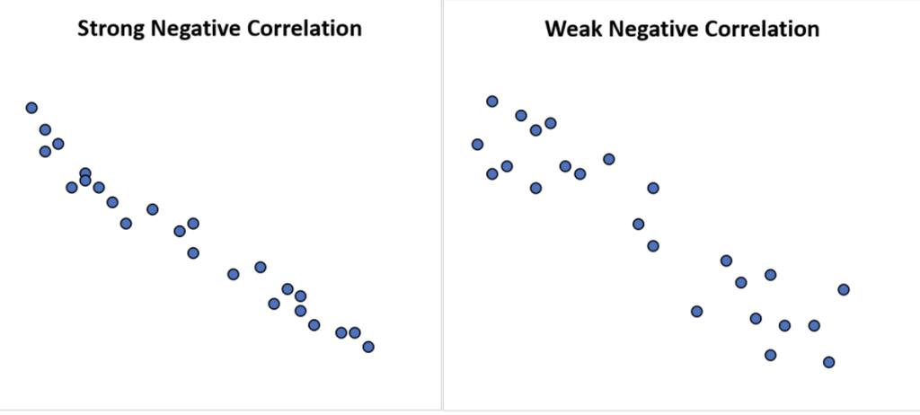

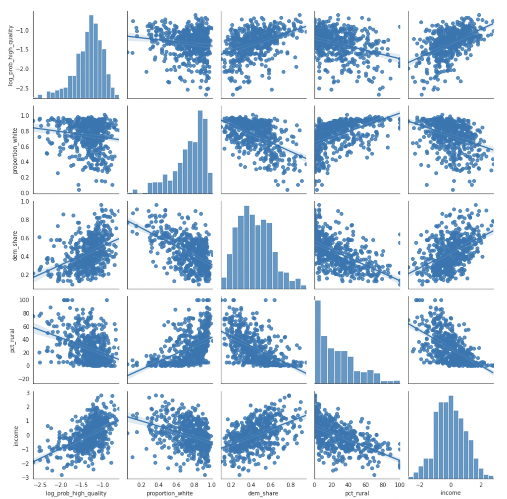

# $p$-values

## Bivariate Hypothesis tests

We don’t want to accidentally (by chance) get a sample that doesn’t reflect the real world.

**Compare:**

- The observed relationship between two variables (IV and DV) in sample data to
- What you would expect to observe if the IV and DV were **NOT** related in the underlying population.

The **more different** the empirically observed relationship is from what we would expect if there were **not** a relationship, the **more confidence** we have that the two variables are related in the underlying population.

→ Can you reject the **null hypothesis** (that there is no relationship)?

**$p$-values** are the statistic that represents this logical exercise.

## $p$-value:

- The $p$robability that we would see the relationship that we are finding because of random chance.
- Or: The probability we would see the observed relationship in our sample data even if there was no relationship in the unobserved population.
- Because the $p$-value is a probability: {0, 1}

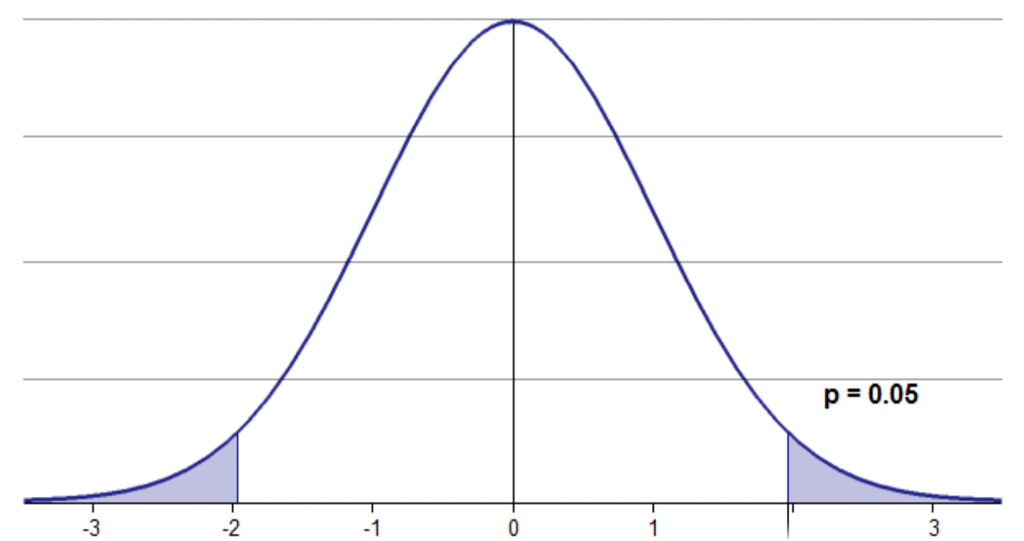

If we want evidence to support for our hypothesis, would we want the $p$-value to be high or low?

## $p$-value:

The **lower the $p$-value**, the **greater confidence** we have that there is a real relationship between our two variables.

> **statistical significance:** A conclusion, based on the observed data, that the relationship between two variables is not due to random chance, and therefore exists in the broader population.

What $p$-values are low enough to demarcate statistical significance (allowing us to reject the null hypothesis)?

- 0.10
- 0.05 → Relationship between X and Y is statistically significant at the *p*=.05 level
- 0.01

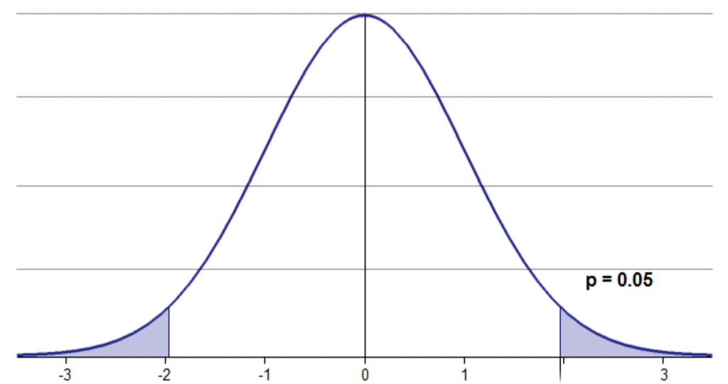

*Human judgments* and conventional practices determine what constitutes statistical significance.

# Bivariate hypothesis tests

## Three bivariate hypothesis tests

- Compare real data from our sample with what we would expect to find if there were no relationship between our IV and DV in the population.
- Lower $p$-values allow us to reject the null hypothesis (that there is no relationship)

| **BIVARIATE HYPOTHESIS TESTS** |  | Independent Variable |  |
| --- | --- | --- | --- |
|  |  | categorical | continuous |
| Dependent Variable | categorical | Tabular analysis | Probit/Logit |
|  | continuous | Difference of means | Correlation coefficient |

**Add to your reading response:** Which test is right for your research question and why?

# Tabular analysis ($\chi^2$):

Testing the relationship between **two categorical variables**

## Tabular Analysis ($\chi^2$)

**Ex:** Is there a relationship between gender and presidential vote (US 2024)?

- IV: Gender (categorical)
- DV: Vote choice (categorical)

**Hypothesis:** Women will be more likely (than men) to vote for Harris.

**Null hypothesis:** There is no relationship between gender and vote choice.

## Tabular Analysis ($\chi^2$)

**Ex:** Is there a relationship between gender and presidential vote (US 2024)?

1. Look at vote breakdowns (overall)

Vote in the 2024 US presidential election

| Candidate | # of resp | Percent |
| --- | --- | --- |
| Harris | 1974 | **55.6** |
| Trump | 1575 | **44.4** |
| Total | 3549 | 100.0 |

Note: Harris and Trump voters who identified as a man or a woman.

Data: ANES 2024, V242067 (Harris/Trump) among V241551 = Man/Woman, unweighted, n = 3,549 (American National Election Studies, 2025). Table format adapted from Kellstedt et al. (2022).

2. What are the expected values (percentages) if there is *no relationship* between gender and vote choice (null hypothesis)?
- Percentage of women voting for Harris? **55.6%**
- Percentage of women voting for Trump? **44.4%**

Is this what we actually observe in the data?

## Tabular Analysis ($\chi^2$)

**Ex:** Is there a relationship between gender and presidential vote (US 2024)?

3. Compare these expected values to what we actually observe across genders.

Gender and vote in the 2024 US presidential election

| Candidate | Man | Woman | Row total |
| --- | --- | --- | --- |
| Harris | 49.8 | 60.7 | **55.6** |
| Trump | 50.2 | 39.3 | **44.4** |
| Column total | 100.0 | 100.0 | 100.0 |

Note: Cell entries are column percentages.

Data: ANES 2024, V242067 × V241551, unweighted; Man/Woman n = 3,549, Man/Woman/Nonbinary n = 3,577 (American National Election Studies, 2025). Table format adapted from Kellstedt et al. (2022, Table 8.3).

Gender and vote in the 2024 US presidential election

| Candidate | Man | Woman | Nonbinary | Row total |
| --- | --- | --- | --- | --- |
| Harris | 49.8 | 60.7 | 96.4 | **55.9** |
| Trump | 50.2 | 39.3 | 3.6 | **44.1** |
| Column total | 100.0 | 100.0 | 100.0 | 100.0 |

Note: Cell entries are column percentages.

- What percentage of women *actually* voted for Harris? Non-binary folks? Men?
- What percentage of women *actually* voted for Trump? Non-binary folks? Men?

It appears that there is a difference between the observed values and what we would expect if there was no relationship between gender and vote choice.

What is the probability that has just occurred in our sample by chance?

## Calculate the tabular analysis manually ($\chi^2$)

Gender and vote in the 2024 US presidential election

| Candidate | Man | Woman |
| --- | --- | --- |
| Harris | O = 824; E = 919.42 | O = 1150; E = 1054.58 |
| Trump | O = 829; E = 733.58 | O = 746; E = 841.42 |

Note: Cell entries are the number observed (O); and the number expected if there were no relationship (E).

Data: ANES 2024 (American National Election Studies, 2025). Table format adapted from Kellstedt et al. (2022, Table 8.9).

- Chi-square ($\chi^2$): $\displaystyle = \sum \frac{(O - E)^2}{E}$

$$\chi^2 = \frac{(824 - 919.42)^2}{919.42} + \frac{(1150 - 1054.58)^2}{1054.58} + \frac{(829 - 733.58)^2}{733.58} + \frac{(746 - 841.42)^2}{841.42}$$

$$\chi^2 = 9.90 + 8.63 + 12.41 + 10.82 = 41.77$$

- Degrees of freedom ($df$) $\displaystyle = (\text{\# of rows} - 1)(\text{\# of columns} - 1) = (2 - 1)(2 - 1) = 1$
- Look up the minimum $\chi^2$ value needed to achieve a $p$-value < 0.05 with one degree of freedom (textbook or online) $\displaystyle = 3.841$
- Compare your $\chi^2$ to the minimum value needed: $\displaystyle = 41.77 > 3.841$

If your $\chi^2$ is greater than the minimum value, you can reject the null hypothesis that there is no relationship.

## Conduct the tabular analysis in `R`

```r
CrossTable(anes_data$pres_vote2024, anes_data$gender,
           prop.r = F, prop.c = T, prop.t = F, prop.chisq = F, chisq = T)
```

```
                        | anes_data$gender
anes_data$pres_vote2024 |       Man |     Woman | Nonbinary | Row Total |
------------------------|-----------|-----------|-----------|-----------|
                 Harris |       824 |      1150 |        27 |      2001 |
                        |     0.498 |     0.607 |     0.964 |           |
------------------------|-----------|-----------|-----------|-----------|
                  Trump |       829 |       746 |         1 |      1576 |
                        |     0.502 |     0.393 |     0.036 |           |
------------------------|-----------|-----------|-----------|-----------|
           Column Total |      1653 |      1896 |        28 |      3577 |
                        |     0.462 |     0.530 |     0.008 |           |
------------------------|-----------|-----------|-----------|-----------|

Pearson's Chi-squared test
------------------------------------------------------------
Chi^2 =  60.60165     d.f. =  2     p =  6.926573e-14
```

*“Hey Claude, what is ‘p = 6.926573e-14’ in decimal format?”*

p = 0.00000000000006926573 (13 zeros after the decimal point before the 6)

So what??? What can we conclude?

- There is a $p < 0.001$ probability that what I’ve observed in my sample occurred by chance.
- I can reject the null hypothesis (that there is no relationship).
- I find support for my hypothesis (that there is a relationship).

# Difference of Means test ($t-statistic$)

Testing the relationship between a **categorical IV** and a **continuous DV**

## Difference of Means test ($t-statistic$)

**Ex:** Is there a relationship between whether a parliamentary democracy has a majority government (relative to a coalition government) and the duration of time the government is in charge?

- Categorical IV: Government type (majority or coalition government)
- Continuous DV: Government duration (# of days each government lasted in office)

**Hypothesis:** Majority governments will be more stable and therefore last longer before someone calls for a snap election.

**Null hypothesis:** There is no relationship between majority/coalition government makeup and government duration.

## Difference of Means test ($t-statistic$)

**Ex:** Is there a relationship between majority/coalition government and duration in charge?

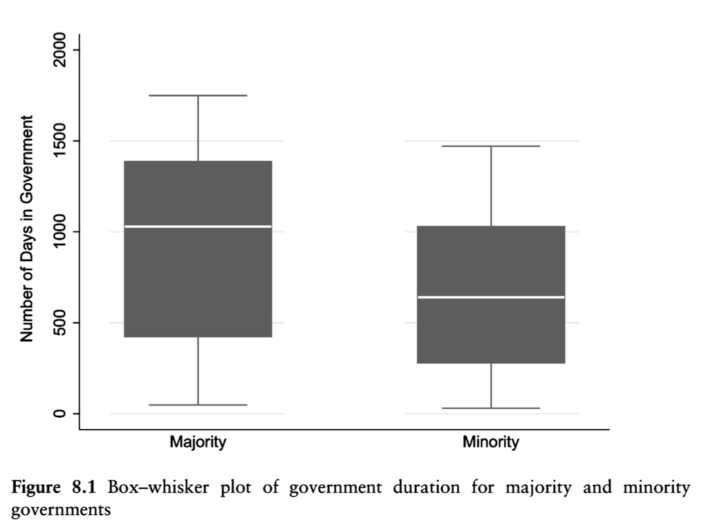

Source: Kellstedt et al. (2022, Figure 8.1)

It appears that there is a difference in the observed means between the two IV options (930 v. 674)…

Does that appear in the sample data by chance?

## Calculate the difference-of-means tests

**Calculate the $t$-statistic manually**

t-statistic:

$$t = \frac{\bar{Y}_1 - \bar{Y}_2}{se(\bar{Y}_1 - \bar{Y}_2)} = 3.44$$

Degrees of freedom:

$$df = n_1 + n_2 - 2 = 175$$

Critical value ($p$ = 0.05, $df$ = 175)**:**

$$3.44 > 1.66$$

**Calculate in `R`**

```r
# DV: duration (days in government)
# IV: govt_type (Majority vs. Minority)
t.test(regime_data$duration ~ regime_data$govt_type, var.equal = TRUE)
```

```
    Two Sample t-test

data:  duration by govt_type
t = 3.44, df = 175, p-value = 0.0007273
alternative hypothesis: true difference in means between
  group Majority and group Minority is not equal to 0
95 percent confidence interval:
 109.1691 403.0309
sample estimates:
mean in group Majority mean in group Minority
                 930.5                  674.4
```

So what??? What can we conclude?

- There is a $p < 0.01$ probability that what I’ve observed in my sample occurred by chance (but that there is no relationship in the underlying population)
- I can reject the null hypothesis (that there is no relationship).
- I find support for my hypothesis (that there is a relationship).

## Difference of Means in `R`: Employment and healthcare

**Ex:** Do people who are working see the system’s healthcare guarantee differently from people who aren’t?

DV: V242448 (how well the system guarantees adequate healthcare; 1 = very well, 4 = not well at all) · IV: V241488x (employment status), recoded *Working now* vs. *Not working*

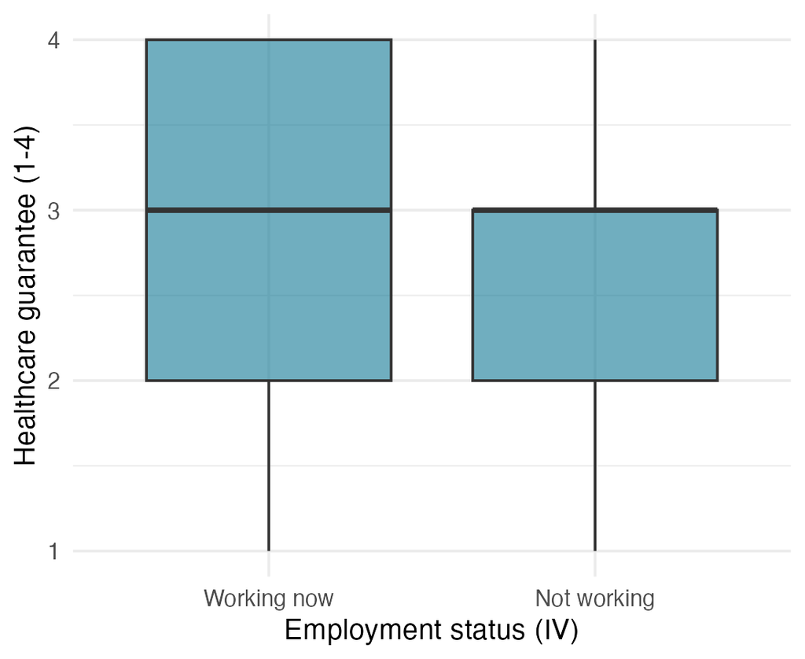

```r
ggplot(anes_health, aes(x = employed, y = health_guarantee)) +
  geom_boxplot(fill = "#107895", alpha = 0.6) +
  labs(x = "Employment status (IV)", y = "Healthcare guarantee (1-4)") +
  theme_minimal(base_size = 14)
```

```r
t.test(health_guarantee ~ employed, data = anes_health)
```

```
    Welch Two Sample t-test

data:  health_guarantee by employed
t = 8.8797, df = 3020, p-value < 2.2e-16
alternative hypothesis: true difference in means between
  group Working now and group Not working is not equal to 0
95 percent confidence interval:
 0.1694342 0.2654654
sample estimates:
mean in group Working now mean in group Not working
                 2.976478                  2.759028
```

Data: ANES 2024, V242448 × V241488x, unweighted, n = 4,669 (American National Election Studies, 2025).

# Correlation coefficient:

A measure of linear association between **two continuous variables**

## Correlation coefficient (Pearson’s $r$)

**Ex:** Is there a relationship between economic growth and the incumbent party’s vote share in U.S. presidential elections?

- Continuous IV: Economic growth (% change in real GDP per capita)
- Continuous DV: Incumbent party’s share of the presidential vote (%)

**Hypothesis:** Stronger economic growth will increase the incumbent party’s vote share.

**Null hypothesis:** There is no relationship between economic growth and incumbent-party vote share.

## Correlation coefficient (Pearson’s $r$)

**Ex:** Is there a relationship between economic growth and incumbent-party vote share?

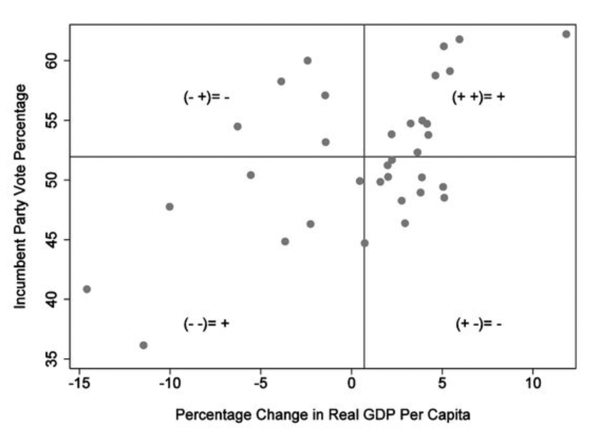

Source: Kellstedt et al. (2022)

- Each point is one U.S. presidential election year ($n$ = 36)
- If most cases in the upper-right / lower-left quadrants → positive covariance (18 election years)
- If most cases in the upper-left / lower-right quadrants → negative covariance (15 election years)

It appears that there is a positive relationship between economic growth and incumbent-party vote share…

What is the probability that has just occurred in our sample by chance?

## Calculate the correlation coefficient

**Calculate Pearson’s $r$ manually**

Covariance:

$$cov_{XY} = \frac{\sum_{i=1}^{n} (X_i - \bar{X})(Y_i - \bar{Y})}{n - 1} = 17.3289$$

Pearson’s $r$ (ranges from −1 to +1)**:**

$$r = \frac{cov_{XY}}{\sqrt{var_X \, var_Y}} = 0.5687$$

t-statistic:

$$t_r = \frac{r\sqrt{n-2}}{\sqrt{1-r^2}} = 4.0319$$

Degrees of freedom: $df = n - 2 = 34$

Critical value ($p$ = 0.05, $df$ = 34)**:**

$$4.0319 > 1.69$$

**Calculate in `R`**

```r
# X: growth (% change in real GDP per capita)
# Y: inc_vote (incumbent party's share of the vote)
cor.test(election_data$growth, election_data$inc_vote)
```

[output not shown]

So what??? What can we conclude?

- There is a $p < 0.001$ probability that what I’ve observed in my sample occurred by chance (but that there is no relationship in the underlying population)
- I can reject the null hypothesis (that there is no relationship).
- I find support for my hypothesis (that there is a relationship).

## Limitations

What hypothesis tests and $p$-values do not allow you to do:

- Bivariate hypothesis tests do not take other (“confounding”) variables into account.
- The first two hypothesis tests do not tell you the direction of the relationship between your variables.
- $p$-values are not **reversible.** (p=0.01 ≠ 99% chance there is a relationship)
- $p$-values do not tell us whether two variables are **causally related**.
- $p$-values are not an indication of the **strength of a relationship** between two variables.
- $p$-values are not a reflection of how well our measure captures the concept we are interested in (≠ validity).
- $p$-values are based on the assumption that your **sample is random**…

Vote in the 2024 US presidential election

| Candidate | # of resp | Percent |
| --- | --- | --- |
| Harris | 1974 | **55.6** |
| Trump | 1575 | **44.4** |
| Total | 3549 | 100.0 |

Note: Harris and Trump voters who identified as a man or a woman.

Data: ANES 2024, V242067 (Harris/Trump) among V241551 = Man/Woman, unweighted, n = 3,549 (American National Election Studies, 2025). Table format adapted from Kellstedt et al. (2022).

*“A large, properly drawn random sample will resemble the population from which it is drawn” ???*

(Survey weights seek to account for this discrepancy.)

## Recap:

**LOGIC (bivariate hypothesis tests):** Compare what we observe in the sample data to what we would expect to observe in the sample if the two variables were **NOT** related in the underlying population.

Use $p$-values (which result from your specific hypothesis test) to evaluate the probability that what we observe occurs in the sample by chance.

If $p$-value is suitably low, you can reject the null hypothesis (that there is no relationship) and conclude that you saw support for your hypothesis.

Using the code and interpreation guidance from this lecture (also provided in the assignment), you can now complete your weekly assignment.

What if my variables are not statistically significant??? Not a problem…Just report the results as is appropriate!

## Reading Response update:

- In your own words: What is a bivariate hypothesis test and what does it accomplish (update your answer)?
- Which bivariate hypothesis test would you use for your analysis and why?
- What is one question you have or one thing you are confused about?

## Readings for next week:

[*Naked Statistics*, Ch 11, “Regression Analysis: The Miracle Elixir”](https://skdreier.github.io/POLS2140/).

[*Fundamentals*, Ch 10, “Two-Variable Regression Models”](https://skdreier.github.io/POLS2140/)

(See the full schedule on the syllabus.)

## TL;DR

- **Bivariate hypothesis tests** compare the relationship we observe in our sample to what we’d expect if X and Y were *unrelated* in the population; the more different they are, the more confident we are that X and Y are related.
- A *p*-value is the probability we’d see the observed relationship even if there were no relationship in the population — lower is better (*p* < .05 is the conventional standard). It says nothing about causation, strength, or validity.
- Pick the test by variable type: **tabular analysis ($\chi^2$)** for categorical IV & DV, **difference of means (*t*)** for categorical IV & continuous DV, **correlation coefficient (Pearson’s *r*)** for continuous IV & DV.
- In practice: calculate the test statistic and df, look up the critical value, and **reject the null** if your statistic is bigger — e.g., gender and 2024 presidential vote: $\chi^2$ = 41.77 > 3.841.

## References

American National Election Studies. (2025). *ANES 2024 Time Series Study Full Release*. Dataset and documentation. https://electionstudies.org/data-center/2024-time-series-study/

Kellstedt, P. M., Whitten, G. D., & Tuch, S. A. (2022). *The fundamentals of social research*. Cambridge University Press.

Wheelan, C. (2013). *Naked statistics: Stripping the dread from the data*. W. W. Norton & Company.